# Superfarmer

Marianna Dzik & Piotr Radziński

08.11.2016r.

# 1 Wstęp

Celem naszego projektu jest stworzenie symulatora gry w Superfarmer dla pojedyńczego gracza wraz z autorską strategią. Następnie liczymy szacowany czas gry na zadanej próbce n gier. W poniższym raporcie przedstawimy działanie projektu krok po kroku.

# 2 Losowanie kostką

## 2.1 Sposób losowania

### 2.1.1 Rzut kostkami

Do losowania wykorzystujemy funkcję sample. Jest ona bardzo wygodna w przypadku losowania kostką wielościenną, na której może być kilka tych samych zwierząt, gdyż pozwala nam wybrać prawdopodobieństwo z jakim dostaniemy konkretne zwierze. Aby ułatwić dalsze obliczenia zawsze losujemy spośród wszystkich możliwych zwierząt, lecz te, których nie możemy otrzymać z danej kostki mają prawdopodobieństwo 0.

```r
rzut_kostkami <- function() {
  #Losowanie kostka.
  kostka_wilk <- sample(1:9, 1, TRUE, prob = c(0, 1 / 12, 1 / 12, 1 / 4, 1 /
                                                2, 0, 0, 0, 1 / 12))
  kostka_lis <- sample(1:9, 1, TRUE, prob = c(1 / 12, 0, 1 / 6, 1 / 6, 1 /
                                               2, 0, 0, 1 / 12, 0))

  #Zmienne przechowujace ilosc poszczegolnych zwierzat na kostce.
  kostki <- rep(0, times = 9)

  kostki[kostka_wilk] <- kostki[kostka_wilk] + 1
  kostki[kostka_lis] <- kostki[kostka_lis] + 1
  return(kostki)
}
```

### 2.1.2 Kontrola wilka i lisa

Funkcja zerująca odpowiednie zwierzaczki i zwracająca wartość stada w wypadku, gdy na kostkach otrzymamy wilka i/lub lisa.

```r
wilk_i_lis <- function(stado. = stado, kostki = rzut) {
  if (kostki[wilk] == 1) {
    if (stado.[duzy_pies] != 0) {
      stado.[duzy_pies] <- stado.[duzy_pies] - 1
    } else {
      stado.[krolik] <- 0
      stado.[owca] <- 0
      stado.[swinia] <- 0
      stado.[krowa] <- 0
    }
  }
  if (kostki[lis] == 1) {
    if (stado.[maly_pies] > 0) {
      stado.[maly_pies] <- stado.[maly_pies] - 1
    } else {
      stado.[krolik] <- 0
    }
  }
  return(stado.)
}
```

### 2.1.3 Zwiekszenie stada

Funkcja rozmnażająca stado w zależności od wyrzuconych na kościach zwierząt, zwraca wektor stada.

```r
rozmnazanie <- function(stado. = stado, kostki = rzut, limit. = limit) {
  for (j in 1:5)
  {
    if (kostki[j] > 0)
      stado.[j] <- min(stado.[j] + as.integer((stado.[j] + kostki[j]) / 2), limit.[j])
  }
  return(stado.)
}
```

### 2.1.4 Losowanie wraz z przeliczeniem stada

W tej funkcji zbieramy rzut kostkami oraz funkcje przeliczające jak stado powinno wyglądać na zakończnie tury.

```r
po_losowaniu <- function(stado.. = stado){
    rzut <- rzut_kostkami()
    stado.. <- wilk_i_lis(stado. = stado.., kostki = rzut)
    stado.. <- rozmnazanie(stado. = stado.., kostki = rzut)
    return(stado..)
}
```

# 3 Nasza Strategia

## 3.1 Opis

Każdy farmer wie, że najłatwiej w życiu jest tym, co posiadają konia. Jednak, gdy nie stać nas na konia okazuje się, że podstawą zróżnicowanego gospodarstwa są tylko i wyłącznie króliki. I psy, ale tych mniej. Niemniej gdy królików jest więcej niż klatek, spoglądając na przywódców wschodnich krain fajnie jest dosiadać konia.

Naszą strategię dzielimy na dwie fazy:

Faza I

Gdy nie mamy konia, naszym celem jest oczywiście go mieć! I czynimy tak gdy tylko jest to możliwe. Wcześniej, chcemy mieć jak najwięcej królików. Dbamy oczywiście o ich bezpieczeństwo za pomocą małego psa, bądź nawet dwóch (gdyby wilk nam zjadł króliczki to za coś chcemy je od niego odkupić). Dbamy oczywiście o dobre warunki do rozmnażania się dla królików, aby nie zabrakło dla nich miejsca (ot, czasem trochę baraniny).

Faza II

Mamy konia! Czego wtedy chce każdy zachłanny farmer? Oczywiście drugiego. Strategia bardzo się nie zmienia: zwracamy troszkę więcej uwaga na co zamieniamy nadmiary królików i nie chcemy trzymać w zagrodzie zbyt dużo niepotrzebnych pysków do żarcia. Staramy się zatem już dążyć do posiadania każdego zwierzaka po jednym. Jeśli brakowało by nam i owiec i świń i wielu innych przyjaznych i puszystych zwierzaczków, ale stać nas by było na drugiego konia, to my bardzo chętnie go zdobywamy! W końcu każdy superfarmer wie, że konie są nieśmiertelne! Gdy mamy dwa konie, oczywiście zamieniamy jednego z nich na całe stato zwierzaczków aby cieszyć się chwałą słowiańskiego rolnika.

## 3.2 Diagram przedstawiający strategię:

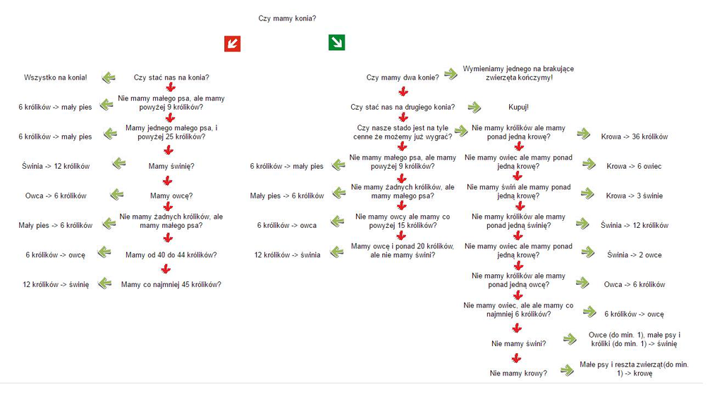

## 3.3 Funkcje użyte do strategii

### 3.3.1 Liczenie wartości stada

Jest to funkcja pomocnicza, zlicza ile nasze stado jest warte “w królikach”. Czyli przelicza ile moglibyśmy otrzymać królików z naszego stada nie biorąc pod uwagę ograniczenia. Korzysta ona z wektora, który przechowuje wartość poszczególnych zwierząt “w królikach” (wartosc_w_krolikach).

```r
wartosc_stada <- function(stado1 = stado, wartosc_w_krolikach1=wartosc_w_krolikach){
  wartosc <- 0
  for(j in 1:7){
    wartosc <- wartosc + stado1[j]*wartosc_w_krolikach1[j]
  }
  return(wartosc)
}
```

### 3.3.2 Zamiana zwierzęcia jednego rodzaju na zwierze innego rodzaju

Jest to funkcja, która jako argumenty przejmuje rodzaj zwierzęcia, które chcemy oddać oraz rodzaj zwierzęcia które chcemy dostać. Mamy dwie opcje:

1. oddawane zwierze jest wiekszej wartości, niż zyskiwane -> obliczmy ile otrzymamy za to zwierze mniejszych zwierzątek i zmieniamy stado,
2. oddajemy kilka zwierząt mniejszej wartości i zyskujemy jedno zwierze wiekszej wartości -> po obliczeniach ile zwierząt musimy oddać zamieniamy wartość stada.

W funkcji tej zakładamy poprawność danych, należy więc je sprawdzić przed uruchomieniem funkcji!

```r
zamien_zwierze_na_zwierze <- function(oddajemy, dostajemy, stado1 = stado, wartosc_w_krolikach1 = wartosc_w_krolikach)
{
  ilosc <- 0
  if( wartosc_w_krolikach1[oddajemy] >= wartosc_w_krolikach1[dostajemy] ){
    ilosc <- wartosc_w_krolikach1[oddajemy]/wartosc_w_krolikach1[dostajemy]
    stado1[oddajemy] <- stado1[oddajemy] -  1
    stado1[dostajemy] <- stado1[dostajemy] + ilosc
  }else{
    ilosc <- wartosc_w_krolikach1[dostajemy]/wartosc_w_krolikach1[oddajemy]
    stado1[oddajemy] <- stado1[oddajemy] -  ilosc
    stado1[dostajemy] <- stado1[dostajemy] + 1
  }
  return(stado1)
}
```

### 3.3.3 Zamiana mniejszych zwierzat różnych rodzajów na jedno większe

Teraz mamy przypadek taki, w którym oddajemy różne rodzaje zwierząt. Funkcja działa dla 3 rodzajów dużych zwierzat: koń, krowa i świnia. Dla każdego zwierzęcia sprawdzamy, które zwierzaki mają od niego mniejszą lub równa wartość. Następnie przechodzimy po tych zwierzakach w kolejności od największej do najmniejszej “wartości w królikach” i wymiwniamy zwierzaczki, aż skończy nam sie ten rodzaj zwierząt lub zwrócimy juz wystarczajaco, aby pokryć wartość krowy. Ważne jest sprawdzenie przed uzyciem funkcji, czy mamy wystarczająco dużo zwierząt.

```r
zamien_na_duze <- function(zwierz, stado1=stado, wartosc_w_krolikach1 = wartosc_w_krolikach){

  if(zwierz == kon){
    kolejnosc_zamiany <- c(duzy_pies, krowa, swinia, owca, maly_pies, krolik)
  }
  if(zwierz == swinia){
    kolejnosc_zamiany <- c(owca, maly_pies, krolik)
  }
  if(zwierz == krowa){
      kolejnosc_zamiany <- c(duzy_pies, swinia, owca, maly_pies, krolik)
  }
  do_oddania <- - wartosc_w_krolikach1[zwierz]
   stado1[zwierz] <- stado1[zwierz] + 1
#Kolejnosc zwierzat ma znaczenie! Przechodze od najwiekszych wartosci, tak aby wartosc kolejnych #zwierzat dzielila wartosc poprzednich. W ten sposob nie oddam za duzo zwierzat
  for(j in kolejnosc_zamiany){
    while(do_oddania < 0 && stado1[j] > 0){
      stado1[j] <- stado1[j] - 1
      do_oddania <- do_oddania + wartosc_w_krolikach1[j]
    }
  }
  return(stado1)
}
```

### 3.3.4 Strategia przed pierwszym koniem

Funkcja której używamy, gdy nie mamy jeszcze żadnego konia.  
Jako argumenty przyjmuje wektory: stado i wartosc_w_krolikach i zwraca nam wektor dwuargumentowy: ruch_zamiana. Mamy tutaj dwie możliwości:

1. chcemy zaminić jeden rodzaj zwierzecia na jeden rodzaj zwierzecia (czyli uzyc funkcji zamin_zwierze_na_zwierze). Wtedy na pierwszym miejscu wektora jest rodzaj zwierzecia, ktory chcemy oddać, a na drugim ten, który chcemy dostać,
2. chcemy zamienić kilka rodzajów mniejszych zwierzątek na jedno większe zwierze (funkcja: zamien_na_duze). Na pierwszym miejscu jest zwierze, które chcemy otrzymać, a na drugim wartość kontrolna 50.

```r
brak_konia <-function(stad = stado, wartosc_w_k = wartosc_w_krolikach ){
    ruch_zamiana <- c(0,0)

      if (wartosc_stada(stad, wartosc_w_k) >= 72) {
          ruch_zamiana <- c(kon, 50)
      } else if ((stad[maly_pies] == 0 && stad[krolik] > 9) || (stad[maly_pies] == 1 && stad[krolik] > 25) ) {
          ruch_zamiana<-c(krolik, maly_pies)
      } else if (stad[krolik]  < 27 && stad[swinia] > 0) {
          ruch_zamiana <- c(swinia, krolik)
      } else if (stad[krolik]  < 33 && stad[owca] > 0 ) {
          ruch_zamiana <-c (owca, krolik)
      } else if (stad[krolik] == 0  && stad[maly_pies] > 0 ) {
       ruch_zamiana <- c(maly_pies, krolik)
      } else if (45 > stad[krolik] && stad[krolik] > 39  && stad[owca] < 23) {
       ruch_zamiana <- c(krolik, owca)
      } else if (46 < stad[krolik] && stad[swinia] < 20) {
        ruch_zamiana <- c(krolik, swinia)
      }
    return(ruch_zamiana)
}
```

### 3.3.5 Strategia, gdy mamy pierwszego konia

Najpierw zdefiniuję funkcje pomocnicze. Wszystkie działają podobnie do poprzedniej.

1. Funkcja rozpatrująca przypadek, gdy mamy jednego konia oraz wartość stada jest w przedziale [127, 144).

```r
jeden_kon_wiecej_niz_127 <- function( stado. = stado ){
      ruch_zamiana <- c(0,0)
      if (stado.[krolik] == 0 && stado.[krowa] > 1 ) {
          ruch_zamiana <- c(krowa, krolik)
      } else if (stado.[owca] == 0 && stado.[krowa] > 1 ) {
          ruch_zamiana <- c(krowa, owca)
      } else if (stado.[swinia] == 0 && stado.[krowa] > 1 ) {
          ruch_zamiana <- c(krowa, swinia)
      } else if (stado.[krolik] == 0 && stado.[swinia] > 1 ) {
          ruch_zamiana <- c(swinia, krolik)
      } else if (stado.[owca] == 0 && stado.[swinia] > 1 ) {
          ruch_zamiana <- c(swinia, owca)
      } else if (stado.[krolik] == 0 && stado.[owca] > 1 ) {
          ruch_zamiana <- c(owca, krolik)
      } else if (stado.[owca] == 0 && stado.[krolik] > 6 ) {
         ruch_zamiana <- c(krolik, owca)
      } else if (stado.[swinia] == 0 ) {
        ruch_zamiana <- c(swinia, 50)
      } else if (stado.[krowa] == 0 ) {
        ruch_zamiana <- c(krowa, 50)
      }
      return (ruch_zamiana)
}
```

2. Funkcja rozpatrująca przypadek, gdy mamy jednego konia oraz wartość stada mniejszą niż 127.

```r
jeden_kon_mniej_niz_127 <- function( stado. = stado ){
        ruch_zamiana <- c(0,0)
       if (stado.[maly_pies] == 0 && stado.[krolik] > 9 ) {
         ruch_zamiana <- c(krolik, maly_pies)
       }else if (stado.[krolik] == 0 && stado.[maly_pies] > 0 ) {
         ruch_zamiana <- c(maly_pies, krolik)
       } else if (stado.[owca] == 0 && stado.[krolik] > 15 ) {
         ruch_zamiana <- c(krolik, owca)
       } else if (stado.[owca] > 0 && stado.[krolik] > 20 && stado.[swinia] == 0 ) {
         ruch_zamiana <- c(krolik, swinia)
       }
      return (ruch_zamiana)
}
```

Funkcja właściwa. Rozpatruje całą naszą strategię w przypadku jednego konia, dzieląc całość w zależności od wartości stada na 3 przypadki: wartość większa niż 144, w przedziale [127, 144) oraz mniejsza niż 127.

```r
jeden_kon <- function( stad = stado, wartosc_w_k = wartosc_w_krolikach ){
      ruch_zamiana <- c(0,0)
  if ( wartosc_stada(stad, wartosc_w_k) >= 144 ) {
       ruch_zamiana <- c(kon, 50)
  } else if (wartosc_stada(stad, wartosc_w_k) >= 127 ) {
      ruch_zamiana <- jeden_kon_wiecej_niz_127(stad)
  } else if (wartosc_stada(stad, wartosc_w_k) < 127) {
      ruch_zamiana <- jeden_kon_mniej_niz_127(stad)
  }
  return (ruch_zamiana)
}
```

### 3.3.6 Stado przy 0 lub 1 koniu

Funkcja, która korzystając z powyższych funkcji zwraca wartość stada po zastosowaniu strategi w przypadku 0 lub 1 konia.  
Sprawdza ona, który rodzaj zamiany wystapił:

1. wiele mniejszych rodzajów na jeden rodzaj (zamien_na_duze)
2. jeden rodzaj na jeden rodzaj (zamien_zwierze_na_zwierze)

```r
brak_lub_1_kon <- function( stad. = stado, wartosc_w_k. = wartosc_w_krolikach ){
        if(stad.[kon] == 0){
        ruch_zmiana <- brak_konia( stad., wartosc_w_k. )
      } else{
              ruch_zmiana <- jeden_kon( stad., wartosc_w_k. )
      }
#Jeśli ruch_zmiana[1] > 0 to wiemy, że jakiś ruch się odbył (jak 0, to nie było żadnego ruchu).
      if(ruch_zmiana[1] > 0){
        if(ruch_zmiana[2] == 50){
          stad. <- zamien_na_duze(ruch_zmiana[1])
        } else {
          stad. <- zamien_zwierze_na_zwierze(ruch_zmiana[1], ruch_zmiana[2])
        }
      }
  return (stad.)
  }
```

### 3.3.7 Wiecej niż jeden koń

Gdy mamy więcej niż jednego konia, to możemy zakończyć grę. Wymieniamy wtedy jednego konia na pozostałe zwierzaki. Idziemy od najwiekszych zwierząt i zwiększamy ich ilość. Ze specyfiki naszej strategii rozpatrujemy tylko przypadek, że mamy za dużo królików. Wtedy zamiast zwiększać jeszcze króliki, zwiększamy owce. Niemniej jednak nie miałoby to większego znaczenia nawet jeśli zwiększylibyśmy na siłę króliki ponad ograniczenie, gdyż za chwilę i tak gra się zakończy (mamy wszystkie zwierzęta!).

```r
wiecej_niz_1_kon <- function( stad = stado ){
      stad[kon] <- stad[kon] - 1
      stad[krowa] <- stad[krowa] + 1
      stad[swinia] <- stad[swinia] + 2
      stad[owca] <- stad[owca] + 1
      if (stad[krolik] < 54){
        stad[krolik] <- stad[krolik] + 6
      } else {
      stad[owca] <- stad[owca] + 1
      }

    return (stad)
  }
```

### 3.3.8 Cała strategia

Zbieramy teraz wszystkie przypadki w jedno: 0 lub 1 koń i więcej niż jeden koń. Funkcja przyjmuje za argumenty wektory: stado i wartość_w_królikach, wywołuje odpowiednią funkcję starategii w zależności od ilości koni i zwraca nową wartość stada.

```r
wymiana_stada <- function( stad.. = stado, wartosc_w_k.. = wartosc_w_krolikach ){
  if (stad..[kon] == 0 || stad..[kon] == 1 )
  {
    stad.. <- brak_lub_1_kon( stad.., wartosc_w_k.. )
  }else if (stad..[kon] > 1 ){
    stad.. <- wiecej_niz_1_kon( stad.. )
  }
  return(stad..)

}
```

# 4 Stałe/warunki początkowe

Przyjmujemy:

n - ilość gier,

dlugosc_gry - przechowuje ilość tur w kolejnych grach,

limit - ograniczenia na ilość zwierząt,

wartosc_w_krolikach - ile za poszczególne zwierzę moglibyśmy mieć królików bez ograniczenia na kroliki.

Ustalamy też stałe o nazwie zwierząt, aby korzystając z wektorów podawać nazwę zwierzęcia, a nie liczbę.

```r
#Ustalamy potrzebne nam stałe:
n=10000
dlugosc_gry <- 1:n

kon <- 1
krowa <- 2
swinia <- 3
owca <- 4
krolik <- 5
duzy_pies <- 6
maly_pies <- 7
lis <- 8
wilk <- 9

lockBinding("kon", globalenv())
lockBinding("krowa", globalenv())
lockBinding("swinia", globalenv())
lockBinding("owca", globalenv())
lockBinding("krolik", globalenv())
lockBinding("maly_pies", globalenv())
lockBinding("duzy_pies", globalenv())
lockBinding("lis", globalenv())
lockBinding("wilk", globalenv())

limit <- c(6, 12, 20, 24, 60, 2, 4)
lockBinding("limit", globalenv())
wartosc_w_krolikach <- c(72, 36, 12, 6, 1, 36, 6)
```

# 5 Kod

Główny kod odpalający naszą symulację superfarmera n razy korzystający z całego naszego funkcyjnego dorobku. Wektor dlugosc_gry zapamiętuje ile trwała każda z poszczególnych gier dla późniejszych wyliczeń.

```r
for (i in 1:n){

  stado <- rep(0, times=7)
  licznik <- 0

  repeat{
    stado <- wymiana_stada()
    if (stado[kon] * stado[krowa] * stado[swinia] * stado[owca] * stado[krolik] != 0) break
    stado <- po_losowaniu()
    licznik <- licznik + 1
  }
  dlugosc_gry[i] <- licznik
}
```

# 6 Średnia długość gry:

```r
summary(dlugosc_gry)
```

```
##    Min. 1st Qu.  Median    Mean 3rd Qu.    Max.
##    8.00   25.00   34.00   38.48   47.00  187.00
```

# 7 Wizualizacja wyników:

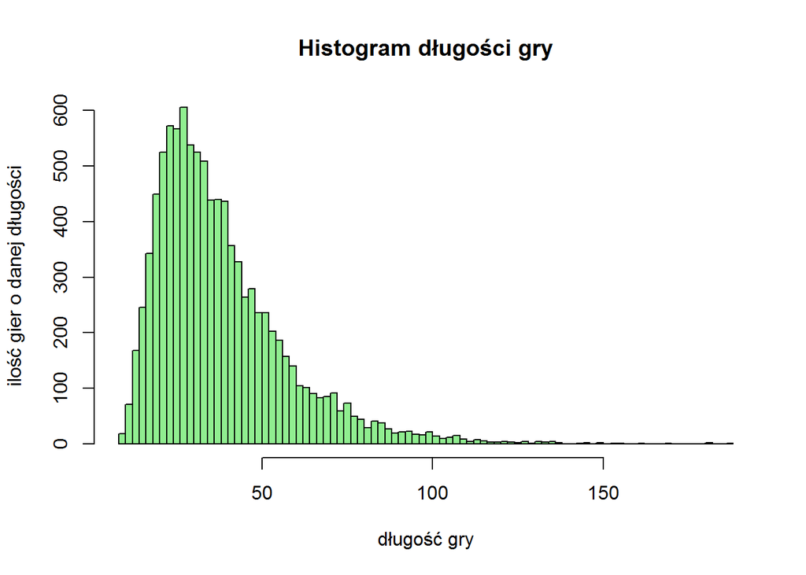

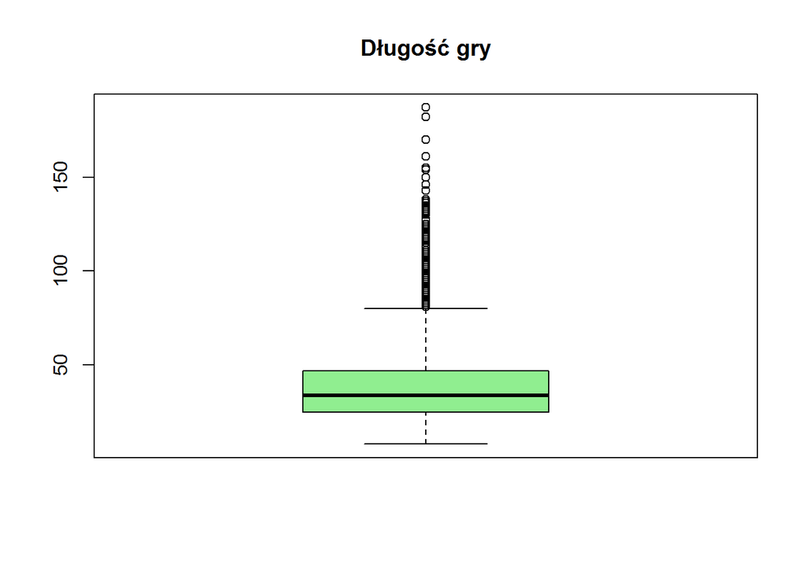

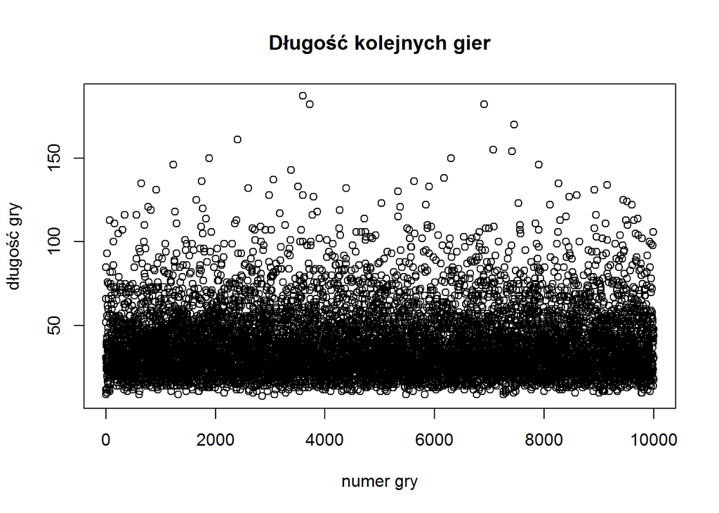

# 8 Podsumowanie

## 8.1 Co osiągneliśmy?

Stworzyliśmy symulację rzutów kostką oraz wymyśliliśmy strategię w grze Superfarmer. Za cel postawiliśmy sobię osiągnięcie niskiej wartości oczekiwanej gry. W tym celu zmienialiśmy niektóre parametry gry, licząc jaka wychodzi wartość oczekiwana dla nich i wybieraliśmy najlepszy wynik.  
Od ostatniej fazy poświęciliśmy czas na zamianę długiego kodu na pomniejsze funkcję, tak, aby kod właściwy był jak najkrótszy.

## 8.2 Co dalej?

W przyszłości można sprawdzić, czy nie da się osiągnąc niższej wartości oczekiwanej. Można również porównać wyniki naszej strategii z prostszymi.